# About Me

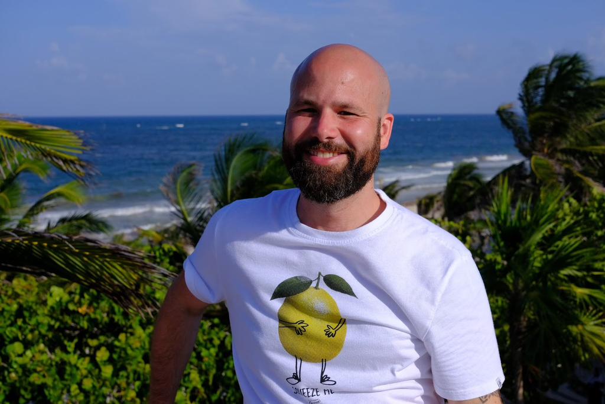

Tulum, Quintana Roo, Mexico - The second happiest place on Earth, after Disneyland

## Professional

My career includes over 15 years of data science, financial strategy, and business analytics for EY, PG&E, KPMG, Centene, and Bloomreach. I use the R and Python programming languages on a daily basis but am much more advanced with my R work. My teams apply data science techniques to empower decision makers with descriptive, predictive, and prescriptive analytics. I help bridge the gap between business needs and IT to develop and deploy automation solutions, predictive algorithms, and interactive web apps.

## Scatter Podcast

In 2019, I launched [Scatter Podcast](https://soundcloud.com/scatterpodcast) to share career tips and insights from data science leaders for students, business managers, and professionals looking to pivot into data science. It was a fun and incredibly rewarding side project but after 30 episodes, I started to feel fatigued with the amount of time it took to plan, record, edit, market, etc. The podcast is on hold *but not dead!*

## Programming & Analytics Skills

- **R**: tidyverse, tidymodels, Quarto, Shiny, Plotly, Leaflet, Prophet, xaringan, XGBoost, Ranger, and many more
- **Other Analytics & Programming Platforms**: Python, Jupyter Notebooks, h2o, GitLab / GitHub, RStudio Connect, AWS S3, AWS Redshift, Google Cloud Platform, BigQuery, SQL, Netlify
- **Microsoft**: Expert-level Excel financial modeler with experiences including nested formulas, XLOOKUPs, Solver for optimization and simulations (yes… in Excel!), macros for psuedo-automated data manipulation, add-in integrations, and more

## Media Appearances

- UC Irvine’s inaugural [Latinx Initiative Conference](https://merage.uci.edu/events/2021/10/2021-lxi-conference.html) (2021-10-15)
- [Data Points: Healthcare and Finance](https://datapoints.griddynamics.com/events/data-points-virtual-summit-healthcare-finance-06-09-2021/) virtual conference hosted by Grid Dynamics (2021-06-09)
  - Watch my presentation [Healthcare Finance Beyond Excel: R for Automation, Time Series Forecasting, and Interactive Reporting](https://youtu.be/LMaPvd4qMQk)
- Scatter Podcast on [UC Irvine News](https://merage.uci.edu/news/2019/06/podcast-launched-by-merage-student-navigates-complex-field-of-data-analytics-and-science.html) (2019-06-13)
- Winner of the [Orange County Predictive Modeling Hackathon](https://twitter.com/oc_rug/status/1130553620456300544?s=20) (2019-05-20)
- Scatter Podcast mention on [Forbes](https://forbes.com/sites/louiscolumbus/2019/04/14/how-to-get-your-data-scientist-career-started) (2019-04-14)